# Digital Lock Pick using FSM and Pattern Generators

In this notebook we will use the FSM Generator to emulate a digital lock, and the Pattern Generator to enumerate a few possible 3-bit sequences. When the Pattern Generator presents the correct pattern the FSM Generator will reach the **open** state.

Original author: Naveen Puroshotham. The code was written for ZYNQ UltraSCALE board Ported to ZYNQ-Z2: Christopher Pham

### Step 1: Download the `logictools` overlay

```python
from pynq.overlays.logictools import LogicToolsOverlay
from pynq.lib.logictools import Waveform

logictools_overlay = LogicToolsOverlay('logictools.bit')
```

### Step 2: Instantiate the Logiclools Controller

Since we are running the Pattern Generator and the FSM Generator simultaneously we must use the Logictools Controller. The Logictools controller is part of the logictools overlay initialized at download time.

```python
logictools_controller = logictools_overlay.logictools_controller
```

[output not shown]

The following cell implements our lock:

For Arduino header, pin numbers 0-13 correspond to D0-D13; pin numbers 14-19 correspond to A0-A5; pin numbers 20-21 correspond to SDA and SCL.

```python
fsm_spec = {
    'inputs': [('reset', 'D0'), ('new_code_digit', 'D1'),
               ('digit_bit3', 'D6'),
               ('digit_bit2', 'D2'),
               ('digit_bit1', 'D3'),
               ('digit_bit0', 'D4')],
    'outputs': [('lock_status', 'D5')],
    'states': ['S0', 'S1', 'S2', 'S3', 'open', 'closed'], # modifying one more state
    'transitions': [['1-----', 'S0', 'S0', '0'],
                    ['1-----', 'S1', 'S0', '0'],
                    ['1-----', 'S2', 'S0', '0'],
                    ['1-----', 'closed', 'S0', '0'],

                    ['00----', 'S0', 'S0', '0'],
                    ['001000', 'S0', 'S1', '0'],
                    ['001001', 'S0', 'closed', '0'],
                    ['001010', 'S0', 'closed', '0'],
                    ['001011', 'S0', 'closed', '0'],
                    ['001100', 'S0', 'closed', '0'],
                    ['001101', 'S0', 'closed', '0'],
                    ['001110', 'S0', 'closed', '0'],
                    ['001111', 'S0', 'closed', '0'],

                    ['00----', 'S1', 'S1', '0'],
                    ['001000', 'S1', 'S2', '0'],
                    ['001001', 'S1', 'closed', '0'],
                    ['001010', 'S1', 'closed', '0'],
                    ['001011', 'S1', 'closed', '0'],
                    ['001100', 'S1', 'closed', '0'],
                    ['001101', 'S1', 'closed', '0'],
                    ['001110', 'S1', 'closed', '0'],
                    ['001111', 'S1', 'closed', '0'],

                    ['00----', 'S2', 'S2', '0'],
                    ['001000', 'S2', 'closed', '0'],
                    ['001001', 'S2', 'closed', '0'],
                    ['001010', 'S2', 'closed', '0'],
                    ['001011', 'S2', 'closed', '0'],
                    ['001100', 'S2', 'closed', '0'],
                    ['001101', 'S2', 'closed', '0'],
                    ['001110', 'S2', 'closed', '0'],
                    ['001111', 'S2', 'closed', '0'],

                    ['00----', 'S3', 'S3', '0'],
                    ['001000', 'S3', 'closed', '0'],
                    ['001001', 'S3', 'closed', '0'],
                    ['001010', 'S3', 'closed', '0'],
                    ['001011', 'S3', 'closed', '0'],
                    ['001100', 'S3', 'closed', '0'],
                    ['001101', 'S3', 'closed', '0'],
                    ['001110', 'S3', 'open', '0'],
                    ['001111', 'S3', 'closed', '0'],

                    ['0-----', 'closed', 'closed', '0'],

                    ['1-----', 'open', 'S0', '1'],
                    ['0-----', 'open', 'open', '1']]}
```

To observe our lock, we also need to set up the trace analyzer. We do this in the following cell:

```python
fsm_generator = logictools_overlay.fsm_generator
fsm_generator.trace(num_analyzer_samples=58)
fsm_generator.setup(fsm_spec, use_state_bits=True, frequency_mhz=1)
```

We observe that the FSM Generator and Trace Analyzer have entered the ready state.

```python
print(logictools_controller.status)
```

```
{'BooleanGenerator': 'RESET', 'PatternGenerator': 'RESET', 'FSMGenerator': 'READY', 'TraceAnalyzer': 'READY'}
```

We can also observe the input and output pins that have been assigned to the inputs and outputs of the FSM Generator:

```python
fsm_generator.input_pins
```

```
['D0', 'D1', 'D6', 'D2', 'D3', 'D4']
```

```python
fsm_generator.output_pins
```

```
['D5', 'D9', 'D8', 'D7']
```

Finally, we can observe the State Diagram for our Digital Lock.

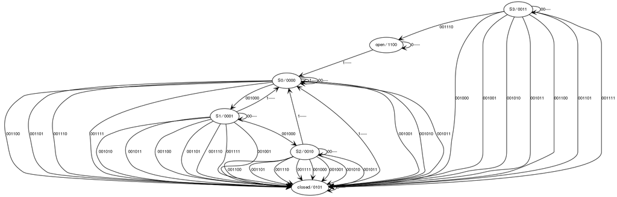

```python
fsm_generator.show_state_diagram()
```